# Macroeconomic Modeling: Orthodox v. Agent-Based

## What do Macroeconomists Do?

As macroeconomists, we seek to provide guidance on the future path of GDP, inflation, interest rates, and debt

Also try to answer questions about the ability to cause/create growth (development).

- As a society, we might consider questions of
  - How do we produce most efficiently?
  - Are goods distributed equitably?
  - What is more important? Growth or cycles?
- Consider the role for:
  - Government spending (Fiscal policy)
  - Tax policy (Fiscal policy)
  - Interest rates (Monetary policy)
  - Growth (structural policy)
    - What helps a country become “rich”

## What are the important macroeconomic growth questions?

- What causes macroeconomic growth?
  - Increases in capital?
  - Increases in technology?
  - Geography?
  - “Good” tax policy and government provided goods?
  - Free markets?
  - Good financial system? Access to credit?
  - Might inequality matter for growth?

## What are the important macroeconomic cycle questions?

- During (and after) a crisis, what should the government do?
  - Increase spending?
  - Cut taxes?
  - Concern about deficits and debt?
  - Cut interest rates?
  - Try to keep inflation low?
  - Help banks and businesses?
  - Help individual households?

## What Should a Macroeconomic Model Do?

Macroeconomic Models might be thought of as providing guidance on the future. They might be helpful in trying to understand the path of economic growth or to help policy makers decide what types of policies are “affordable” or worth it in both the short and long-term.

- These models should aim to have at least a few components
  - How do we produce goods?
    - Use \(L\) and \(K\) with technology to produce output? (i.e., \(Y=AK^\alpha L^{1-\alpha}\))
  - How do we sell goods that are produced?
    - All production can be bought, saved, wasted
    - Households need income
    - How much do households consume?
  - What does the labor market look like?
    - Does everyone get hired (i.e., inelastic labor supply & demand)
    - Do you have a labor market? If so, how is it structured? What are incentives?
  - How is government policy implemented?
    - Do we give money directly to people, firms, or just consume directly?
    - What is benefit of government spending?

## Assumptions in a Typical Macroeconomic Model

- Goods produced by and sold by firms (a.k.a., Aggregate Supply)
  - Solow Growth Model is one way
- Household demand
  - Representative agent model with optimizing behavior
    - Maximize lifetime well-being in present value
      - \(c_{today} + \frac{c_{future}}{1+R} = f_{today} + y_{today} + \frac{y_{future}}{1+R}\)
      - \(U = u(c_{today}) + \beta u(c_{future})\)
      - Use a ‘well behaved’ utility function
    - Take account of discount rates, wealth, income
  - Why do we save?
    - Future consumption
    - Precaution
    - Bequest
  - Our “Euler Equation”
    - \(u'(c_{today}) = \beta(1+R)u'(c_{future})\)

## Who Makes & Uses Macroeconomic Models?

A typical model might be one employed by the Congressional Budget Office (CBO), Office of Management and Budget (OMB), or Joint Committee on Taxation (JCT). These organizations are non-partisan, though OMB provides the executive branch projections

Other private organizations like the Penn Wharton Budget Model (PWBM), American Enterprise Institute (AEI), and Tax Policy Center (TPC) produce separate estimates. Some are more partisan than others.

There are also private models used by academics that make these types of predictions.

- CBO Makes a “Baseline” Economic Forecast for 10 and 30 years
- Cost projections for proposed legislation
  - Consider potential growth effects
  - Consider impacts to federal government revenues and expenditures

## CBO Baseline Model

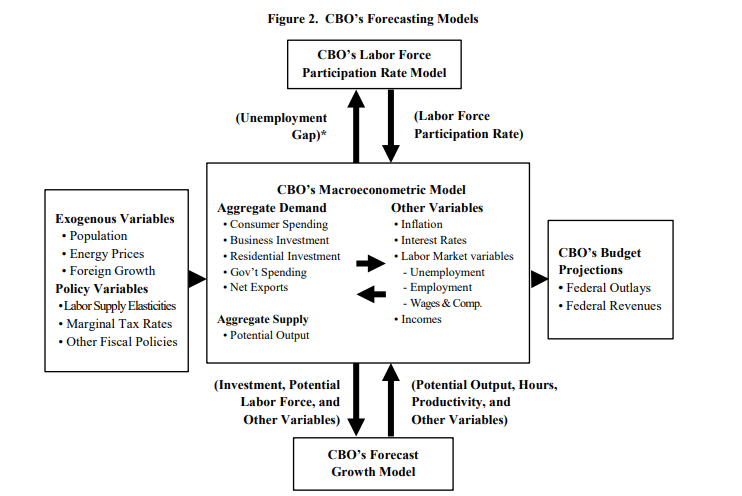

CBO Baseline Model

## Are The Models Any Good?

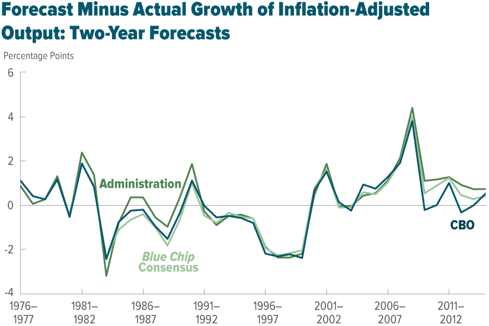

CBO Success Rate

## Is There Reason to Doubt “Representative Agents”

- Yes!
- Problems of “modeling shocks” from long-run growth path.
- Can not be falsified. Bad forecast? Model just needed modification!
- Heterogeneity is poorly modeled (constrained v. perfect liquidity).
- What if people do not always behave rationally, or shift behavior in a crisis? Herding or contagion.
- Markets clear. No involuntary unemployment. No market failure.
- Solved with frictions. Implication… eliminate frictions?

## What is the “Agent-Based” Approach?

- Incorporate bounded rationality & incomplete markets.
- Workers and firms interact and adapt over time.
- No assumption of clearing markets. Role for search.
- Large endogenous shocks from small events.
- Create distributions that closely resemble real world data. Gallegati et al. (2003), DelliGatti et al. (2007)
- Complex Adaptive Trivial Systems (C@S or CATS).
- Rule based “evidence inspired behavior” & no centralized solving mechanism. Not an equilibrium model.
- Policy Applications? Russo et al. (2007): Fiscal, DelliGatti et al. (2005): Monetary.

## One Early Example - Financial Fragility

- Sequential Fragility Model with Only Firms and Banks (No Labor).
- Delli Gatti et al. (2005)

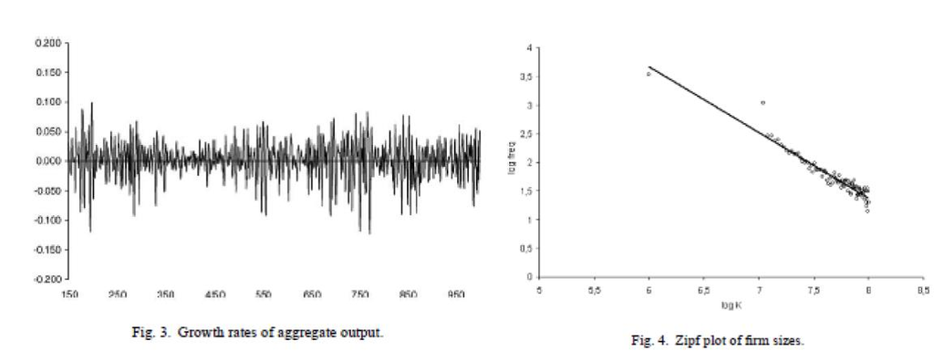

Power Laws in Firm Sizes and Endogenous Volatility

## Another Early Example - Sequential Model with Labor, Firms, and Banks.

- Gaffeo (2008)

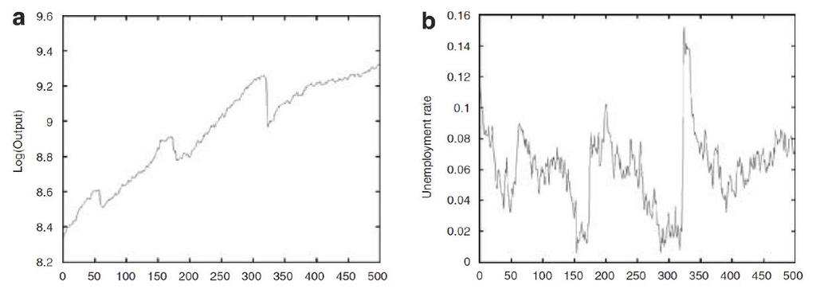

Apparent “Trend” Growth and Unemployment Cycles

## A Third Early Example - Agent-Based Models and Policy

- Tax Policy with Labor, Firms, and Banks: Russo (2007)

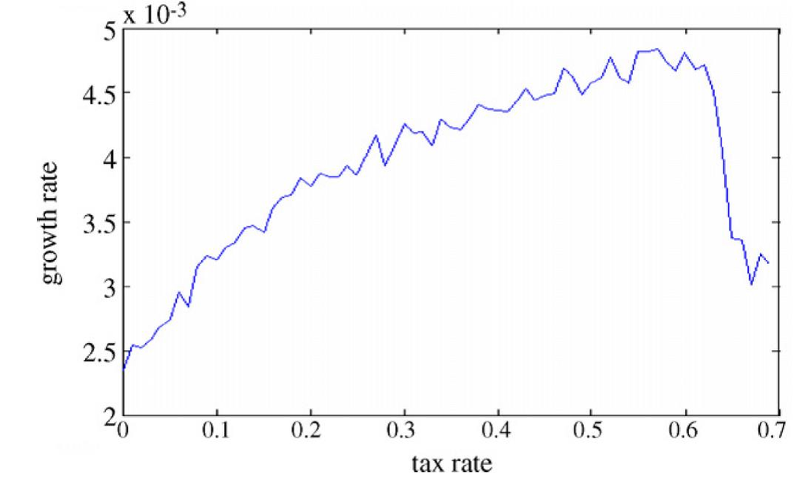

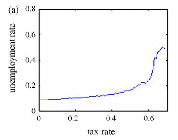

## My Interests and Contributions

- Financial Fragility models often have no labor market.
- Gaffeo et al. (2008) and Russo et al. (2007) examine labor production.
- Adaptation is “backward-looking, sequential, and path dependent” (Gaffeo 2008)
- Previous work is not calibrated.
- Taxes are not primarily collected via corporate taxation.

## Neveu (2013)

- Incorporate progressive income taxes into CATS model with redistribution.
- Use a novel approach in the HIA literature to measure cycles.
- Calibrate model to empirical data.
- Compare fiscal stimulus, tax cut stimulus, and “austerity” plan.
- Find evidence suggesting that stimulus treatment considered reduces length of recessions or lengthens expansions.
- Equity vs. efficiency debate.

## How Does My Macro Model Work?

1. Solvent firms invest a “random” portion of previous profits into R&D, may be aided by government R&D policy.
2. Replace dead firms from the labor intensive (i.e., low tech).
3. Capital stock is “stock-flow” consistent.
4. Technological growth is “randomly” successful.
5. Firms post jobs based on previous sales success and technology.
6. Households shop for jobs w/ limited search & preferential attachment.
7. Production occurs, prices are set based on previous success. Firms borrow funds to pay workers if necessary. Interest rates based on borrowing needs.
8. Employed pay taxes.
9. Unemployed collect “dole.”
10. Households shop for goods w/ limited search & preferential attachment.
11. Consumption is based on income, wealth, and previous consumption.
12. Firms collect revenues, repay debts, calculate profits, and pay taxes.
13. Repeat.

## Firm Behavior

- Produce homogeneous non-storable good. Fixed number of firms (\(I=30\)).
- Net worth evolves with profits and losses.
- Firms with positive equity at \(t\) continue to produce. Negative equity firms go bankrupt.
- Firms are replaced with replications of the most labor-intensive firms. (Lowest 10% of firms in terms of technology).
- R&D is combination of all resources and evolves.
- Labor demand determined from expected demand which equals desired production, \(D^e_{i,t}=Y^d_{i,t}\).
- Expected demand rises if goods “stock out” or declines if carrying inventory.

Price and Expected Demand Evolution

- Price rises for firms who “stock out”
- Price falls for firms who did not sell goods

## Labor Market

Workers enter the labor market by sending out applications. Individuals have specific reservation wages.

Firms might be Firing: \(L^d_{i,t}<L^d_{i,t-1}\). Sort workers and fire randomly.

Firms might be Hiring: \(L^d_{i,t}>L^d_{i,t-1}\). Sort applications and hire lowest wages first.

- Can Firms Pay?
  - If firms have adequate equity to pay their wage bill, they proceed to production. Firms with insufficient equity resort to single-period borrowing.
  - Labor (\(L_t\)) is summed across workers, the remainder are unemployed (\(U_t=N-L_t\)).
- Wages
  - Include binding minimum reservation wage set at 45% of the median reservation wage from time \(t-1\).
  - Workers request higher pay if they were employed and no contract
  - Workers can remain under contract
  - Workers might reduce pay request if they were unemployed at \(t-1\)

## Labor Earnings and Taxes

- Wages paid immediately after hiring.
  - Labor earnings are taxed at rate \(\tau_1=7.5\%, \tau_2=15\%,\) and \(\tau_3=22.5\%\) in order to fund government spending which will go towards maintaining a minimum level of consumption and R&D. Corporate tax rates are set at \(\tau_c=22.5\%\).
- Redistribution set to be 100% to unemployed.
- Consumption for the unemployed can be funded out of redistributed government revenue.
- Employees receive individual specific contracts.

## Consumption Markets

- Consumers have \(\text{Deposits}_{j,t}=w_{j,t}+\upsilon_{j,t}\) in money to spend.
- Individuals with more equity set aside a greater portion of their income for savings.
  - Consumers shop at a few firms to try and purchase up to the total amount of income set aside.
  - Consumers have preferential attachment to firms in terms of prices. Weighted probability of selection.
  - Minimum consumption is adaptive. If consumers can exceed minimum consumption, they increase minimum for \(t+1\).
  - If consumers fail to meet minimum consumption they reduce their demands. High wealth accumulated through high wages, not low consumption!
  - Those with high wealth and low (or no) income will slowly adapt their consumption downward.
  - Households can hold firm equity, government bonds, or cash.
  - All government issued debt must be held by the public.
- Individuals enter consumption market, and shop until consumption is filled or they are locked out of markets.
- Those who are locked out have involuntary savings, increasing net equity.

## Some Results 1

The model is able to create cyclical regularities!

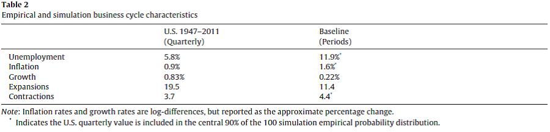

Comparing Simulation Statistics to Stylized Facts

## Some Results 2

But not always!

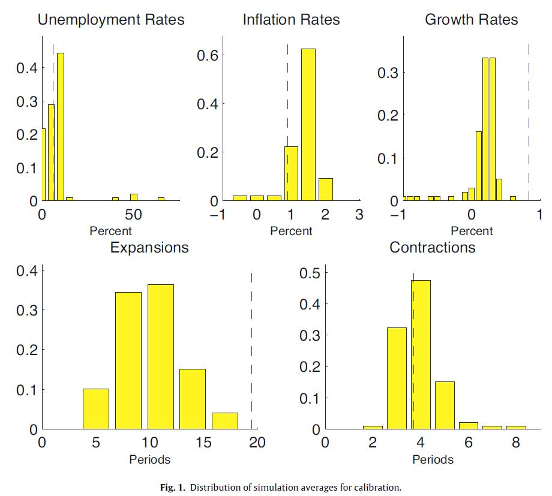

Simulation Images

## Impacts on Business Cycles of Treatments

1. Deficit financed fiscal stimulus. 7.5% increase in spending.
2. Tax cut and spending cut. 25% cut in tax rates and corresponding reduction in spending.
3. Deficit financed tax cut. 25% cut in tax rates, maintain spending levels.

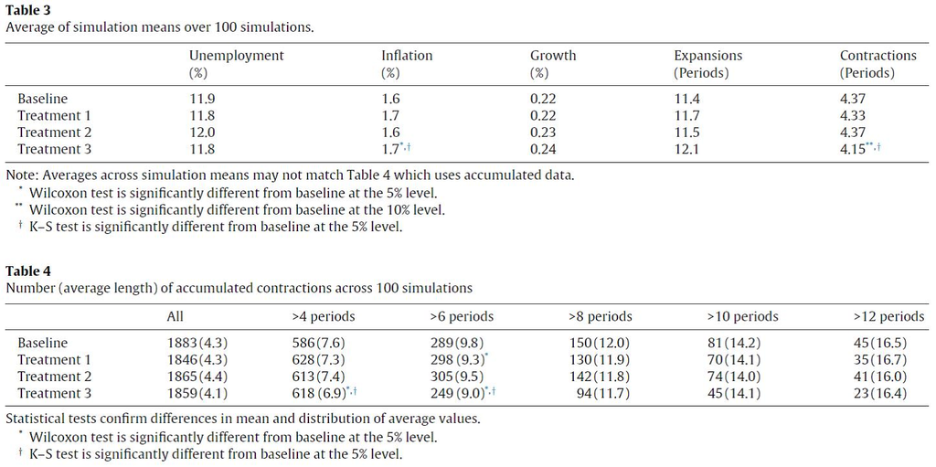

Impacts on Business Cycles

## Visualizing ONE Simulation

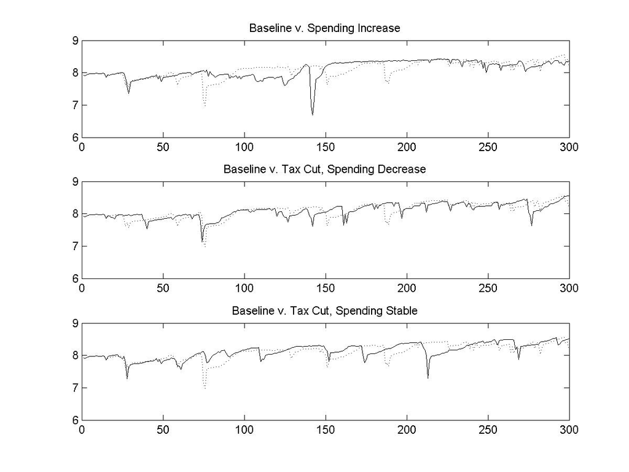

Visualizing Output in Baseline (dotted) & Treatments (solid)

## So What Does This Show?

- Model shows:
  - Spending in recession lengthens recoveries
  - Tax cuts in recession shortens recessions
  - Austerity seems to have no impact either way
- CBO (and others) trying to predict future based on certain existing reality
  - Might be good if nothing changes
  - Downside? This is difficult to deal with shocks
  - Equilibrium model - when you have been pushed away, you will return… just because!
- The ABM Model?
  - Good at general scenarios of crises
  - Better at thinking about how certain aspects might impact world
  - Not good at prediction…
  - Better at realistic micro foundations
  - Bad? Not great at “closing” the model